## 組員姓名

林昱珊 許凱晶

## 分析議題背景

登革熱（Dengue fever），是一種由登革病毒所引起的急性傳染病，這種病毒會經由蚊子傳播給人類。並且依據不同的血清型病毒，分為Ⅰ、Ⅱ、Ⅲ、Ⅳ四種型別，而每一型都具有能感染致病的能力。 全球登革熱的好發地區，主要集中在熱帶、亞熱帶等有埃及斑蚊和白線斑蚊分布的國家，隨著全球化發展逐漸便利，各國之間相互流通及往返也趨於頻繁，自1980年代之後，登革熱也開始向各國蔓延，成為嚴重的公共衛生問題。臺灣位於亞熱帶地區，像這樣有點熱、又有點溼的環境，正是蚊子最喜歡的生長環境，為登革熱流行高風險地區。 預防此疾病的議題受大家的重視，因為少部分患者可能因此受生命的威脅，雖然有發展登革熱疫苗，但預防還是勝於治療，除了減少接觸斑紋，也需要減少斑紋滋生地和數目。

## 分析動機

秋夏季節來臨有些疾病也伴隨著而來，分析疾病的資料有助於我們對環境的了解，也可以讓我們避免疾病的惡化並改善地區環境的整潔。

## 使用資料

我們從疾病管制署的開放平台分析有關登革熱的開放式資料，登革熱的資料一共八筆，而我們分析的是“地區年齡統計表-登革熱”這個資料。

```r
#這是R Code Chunk
library(readr)
#Age_County_Gender_061 <- read.csv("C:/Users/user/Downloads/Age_County_Gender_061.csv",fileEncoding = "big5")
Age_County_Gender_061 <- read.csv("~/GitHub/b0344139_hw6/Age_County_Gender_061.csv",fileEncoding = "big5")
```

## 資料處理與清洗

處理資料

```r
#這是R Code Chunk
library(dplyr)
Age_County_Gender_061F<-Age_County_Gender_061[grepl("F",Age_County_Gender_061$性別),]
Age_County_Gender_061F<-select(Age_County_Gender_061F,發病年份:確定病例數,-是否為境外移入)
Age_County_Gender_061F<-rename(Age_County_Gender_061F,女生=性別)
Age_County_Gender_061M<-Age_County_Gender_061[grepl("M",Age_County_Gender_061$性別),]
Age_County_Gender_061M<-select(Age_County_Gender_061M,發病年份:確定病例數,-是否為境外移入)
Age_County_Gender_061M<-rename(Age_County_Gender_061M,男生=性別)
a<-full_join(Age_County_Gender_061F,Age_County_Gender_061M,by=c("發病年份","發病月份","縣市","鄉鎮","年齡層"))

knitr::kable(head(Age_County_Gender_061F,50))
```

|  | 發病年份 | 發病月份 | 縣市 | 鄉鎮 | 女生 | 年齡層 | 確定病例數 |
| --- | --- | --- | --- | --- | --- | --- | --- |
| 2 | 2003 | 12 | 新北市 | 三重區 | F | 40-44 | 1 |
| 4 | 2004 | 11 | 屏東縣 | 屏東市 | F | 60-64 | 4 |
| 6 | 2004 | 2 | 基隆市 | 信義區 | F | 20-24 | 1 |
| 8 | 2004 | 8 | 高雄市 | 鳳山區 | F | 15-19 | 1 |
| 9 | 2004 | 9 | 屏東縣 | 屏東市 | F | 35-39 | 1 |
| 10 | 2004 | 9 | 屏東縣 | 屏東市 | F | 50-54 | 2 |
| 11 | 2004 | 9 | 屏東縣 | 屏東市 | F | 65-69 | 1 |
| 15 | 2005 | 12 | 台北市 | 信義區 | F | 25-29 | 1 |
| 18 | 2006 | 10 | 高雄市 | 前鎮區 | F | 50-54 | 4 |
| 19 | 2006 | 11 | 高雄市 | 三民區 | F | 35-39 | 1 |
| 23 | 2006 | 7 | 台北市 | 大安區 | F | 55-59 | 1 |
| 25 | 2006 | 8 | 桃園市 | 八德區 | F | 40-44 | 1 |
| 26 | 2006 | 8 | 高雄市 | 前鎮區 | F | 60-64 | 5 |
| 27 | 2006 | 8 | 高雄市 | 新興區 | F | 50-54 | 1 |
| 28 | 2006 | 9 | 高雄市 | 苓雅區 | F | 70+ | 2 |
| 29 | 2006 | 9 | 高雄市 | 鳥松區 | F | 60-64 | 1 |
| 30 | 2007 | 10 | 台南市 | 南區 | F | 10-14 | 1 |
| 31 | 2007 | 10 | 台南市 | 關廟區 | F | 65-69 | 2 |
| 34 | 2007 | 11 | 台南市 | 安南區 | F | 65-69 | 1 |
| 40 | 2007 | 7 | 台南市 | 永康區 | F | 25-29 | 1 |
| 42 | 2007 | 7 | 高雄市 | 三民區 | F | 35-39 | 1 |
| 47 | 2007 | 9 | 台南市 | 東區 | F | 35-39 | 1 |
| 54 | 2008 | 11 | 高雄市 | 苓雅區 | F | 45-49 | 1 |
| 55 | 2008 | 11 | 高雄市 | 鼓山區 | F | 15-19 | 1 |
| 56 | 2008 | 11 | 高雄市 | 鼓山區 | F | 70+ | 1 |
| 60 | 2009 | 10 | 台南市 | 永康區 | F | 55-59 | 1 |
| 65 | 2009 | 11 | 高雄市 | 三民區 | F | 20-24 | 1 |
| 67 | 2009 | 12 | 台北市 | 信義區 | F | 30-34 | 1 |
| 72 | 2009 | 3 | 台北市 | 中正區 | F | 25-29 | 1 |
| 73 | 2009 | 4 | 嘉義縣 | 新港鄉 | F | 25-29 | 1 |
| 76 | 2009 | 8 | 高雄市 | 小港區 | F | 30-34 | 1 |
| 77 | 2009 | 8 | 高雄市 | 小港區 | F | 55-59 | 2 |
| 80 | 2010 | 10 | 台南市 | 中西區 | F | 15-19 | 1 |
| 81 | 2010 | 10 | 台南市 | 東區 | F | 40-44 | 1 |
| 82 | 2010 | 10 | 台南市 | 關廟區 | F | 55-59 | 1 |
| 83 | 2010 | 10 | 高雄市 | 三民區 | F | 5-9 | 2 |
| 86 | 2010 | 10 | 高雄市 | 苓雅區 | F | 60-64 | 3 |
| 88 | 2010 | 11 | 台南市 | 安南區 | F | 25-29 | 1 |
| 89 | 2010 | 11 | 高雄市 | 三民區 | F | 15-19 | 1 |
| 90 | 2010 | 11 | 高雄市 | 左營區 | F | 25-29 | 1 |
| 91 | 2010 | 11 | 高雄市 | 前鎮區 | F | 30-34 | 1 |
| 92 | 2010 | 12 | 高雄市 | 前鎮區 | F | 70+ | 1 |
| 93 | 2010 | 12 | 高雄市 | 苓雅區 | F | 50-54 | 2 |
| 96 | 2010 | 8 | 高雄市 | 鼓山區 | F | 30-34 | 2 |
| 98 | 2010 | 9 | 台中市 | 潭子區 | F | 40-44 | 1 |
| 99 | 2010 | 9 | 高雄市 | 新興區 | F | 65-69 | 1 |
| 102 | 2004 | 11 | 屏東縣 | 屏東市 | F | 45-49 | 4 |
| 107 | 2004 | 8 | 屏東縣 | 屏東市 | F | 45-49 | 1 |
| 109 | 2005 | 10 | 台北市 | 北投區 | F | 15-19 | 1 |
| 111 | 2005 | 7 | 苗栗縣 | 南庄鄉 | F | 5-9 | 1 |

```r
knitr::kable(head(Age_County_Gender_061M,50))
```

|  | 發病年份 | 發病月份 | 縣市 | 鄉鎮 | 男生 | 年齡層 | 確定病例數 |
| --- | --- | --- | --- | --- | --- | --- | --- |
| 1 | 2003 | 10 | 高雄市 | 楠梓區 | M | 45-49 | 1 |
| 3 | 2003 | 7 | 台南市 | 中西區 | M | 50-54 | 1 |
| 5 | 2004 | 11 | 高雄市 | 苓雅區 | M | 15-19 | 1 |
| 7 | 2004 | 4 | 高雄市 | 三民區 | M | 35-39 | 1 |
| 12 | 2004 | 9 | 屏東縣 | 屏東市 | M | 40-44 | 2 |
| 13 | 2004 | 9 | 新北市 | 中和區 | M | 70+ | 1 |
| 14 | 2005 | 10 | 屏東縣 | 里港鄉 | M | 40-44 | 1 |
| 16 | 2005 | 5 | 桃園市 | 大園區 | M | 35-39 | 1 |
| 17 | 2006 | 10 | 高雄市 | 林園區 | M | 45-49 | 1 |
| 20 | 2006 | 11 | 新北市 | 三重區 | M | 40-44 | 1 |
| 21 | 2006 | 12 | 屏東縣 | 恆春鎮 | M | 25-29 | 1 |
| 22 | 2006 | 4 | 高雄市 | 左營區 | M | 45-49 | 1 |
| 24 | 2006 | 7 | 高雄市 | 前鎮區 | M | 35-39 | 2 |
| 32 | 2007 | 11 | 台南市 | 永康區 | M | 10-14 | 2 |
| 33 | 2007 | 11 | 台南市 | 永康區 | M | 55-59 | 1 |
| 35 | 2007 | 11 | 台南市 | 東區 | M | 70+ | 5 |
| 36 | 2007 | 11 | 高雄市 | 岡山區 | M | 25-29 | 1 |
| 37 | 2007 | 6 | 台南市 | 北區 | M | 10-14 | 1 |
| 38 | 2007 | 6 | 台南市 | 安平區 | M | 1 | 1 |
| 39 | 2007 | 7 | 台南市 | 大內區 | M | 50-54 | 1 |
| 41 | 2007 | 7 | 台南市 | 南區 | M | 55-59 | 1 |
| 43 | 2007 | 7 | 高雄市 | 仁武區 | M | 40-44 | 1 |
| 44 | 2007 | 8 | 台南市 | 關廟區 | M | 70+ | 1 |
| 45 | 2007 | 8 | 新北市 | 新莊區 | M | 40-44 | 1 |
| 46 | 2007 | 9 | 台南市 | 中西區 | M | 30-34 | 1 |
| 48 | 2007 | 9 | 台南市 | 東區 | M | 40-44 | 2 |
| 49 | 2008 | 1 | 台南市 | 南區 | M | 50-54 | 1 |
| 50 | 2008 | 1 | 屏東縣 | 新園鄉 | M | 30-34 | 1 |
| 51 | 2008 | 10 | 台北市 | 士林區 | M | 15-19 | 1 |
| 52 | 2008 | 10 | 高雄市 | 苓雅區 | M | 15-19 | 3 |
| 53 | 2008 | 11 | 桃園市 | 大園區 | M | 55-59 | 1 |
| 57 | 2008 | 7 | 雲林縣 | 斗六市 | M | 50-54 | 1 |
| 58 | 2008 | 8 | 新北市 | 中和區 | M | 35-39 | 1 |
| 59 | 2008 | 9 | 高雄市 | 鳳山區 | M | 55-59 | 1 |
| 61 | 2009 | 10 | 屏東縣 | 屏東市 | M | 60-64 | 1 |
| 62 | 2009 | 10 | 高雄市 | 前鎮區 | M | 40-44 | 2 |
| 63 | 2009 | 10 | 高雄市 | 鼓山區 | M | 50-54 | 1 |
| 64 | 2009 | 10 | 高雄市 | 鳳山區 | M | 60-64 | 1 |
| 66 | 2009 | 11 | 高雄市 | 旗津區 | M | 65-69 | 2 |
| 68 | 2009 | 12 | 屏東縣 | 屏東市 | M | 50-54 | 1 |
| 69 | 2009 | 12 | 高雄市 | 三民區 | M | 35-39 | 1 |
| 70 | 2009 | 12 | 新北市 | 三重區 | M | 50-54 | 1 |
| 71 | 2009 | 2 | 宜蘭縣 | 員山鄉 | M | 10-14 | 1 |
| 74 | 2009 | 7 | 台北市 | 萬華區 | M | 50-54 | 1 |
| 75 | 2009 | 7 | 苗栗縣 | 三義鄉 | M | 35-39 | 1 |
| 78 | 2009 | 8 | 高雄市 | 小港區 | M | 60-64 | 2 |
| 79 | 2009 | 9 | 高雄市 | 大寮區 | M | 15-19 | 1 |
| 84 | 2010 | 10 | 高雄市 | 大社區 | M | 35-39 | 1 |
| 85 | 2010 | 10 | 高雄市 | 阿蓮區 | M | 55-59 | 1 |
| 87 | 2010 | 11 | 台北市 | 松山區 | M | 25-29 | 1 |

```r
knitr::kable(head(a,50))
```

| 發病年份 | 發病月份 | 縣市 | 鄉鎮 | 女生 | 年齡層 | 確定病例數.x | 男生 | 確定病例數.y |
| --- | --- | --- | --- | --- | --- | --- | --- | --- |
| 2003 | 12 | 新北市 | 三重區 | F | 40-44 | 1 | NA | NA |
| 2004 | 11 | 屏東縣 | 屏東市 | F | 60-64 | 4 | M | 1 |
| 2004 | 2 | 基隆市 | 信義區 | F | 20-24 | 1 | NA | NA |
| 2004 | 8 | 高雄市 | 鳳山區 | F | 15-19 | 1 | NA | NA |
| 2004 | 9 | 屏東縣 | 屏東市 | F | 35-39 | 1 | M | 5 |
| 2004 | 9 | 屏東縣 | 屏東市 | F | 50-54 | 2 | NA | NA |
| 2004 | 9 | 屏東縣 | 屏東市 | F | 65-69 | 1 | M | 2 |
| 2005 | 12 | 台北市 | 信義區 | F | 25-29 | 1 | NA | NA |
| 2006 | 10 | 高雄市 | 前鎮區 | F | 50-54 | 4 | M | 4 |
| 2006 | 11 | 高雄市 | 三民區 | F | 35-39 | 1 | NA | NA |
| 2006 | 7 | 台北市 | 大安區 | F | 55-59 | 1 | NA | NA |
| 2006 | 8 | 桃園市 | 八德區 | F | 40-44 | 1 | NA | NA |
| 2006 | 8 | 高雄市 | 前鎮區 | F | 60-64 | 5 | M | 1 |
| 2006 | 8 | 高雄市 | 新興區 | F | 50-54 | 1 | NA | NA |
| 2006 | 9 | 高雄市 | 苓雅區 | F | 70+ | 2 | M | 1 |
| 2006 | 9 | 高雄市 | 鳥松區 | F | 60-64 | 1 | NA | NA |
| 2007 | 10 | 台南市 | 南區 | F | 10-14 | 1 | NA | NA |
| 2007 | 10 | 台南市 | 關廟區 | F | 65-69 | 2 | NA | NA |
| 2007 | 11 | 台南市 | 安南區 | F | 65-69 | 1 | M | 1 |
| 2007 | 7 | 台南市 | 永康區 | F | 25-29 | 1 | M | 1 |
| 2007 | 7 | 高雄市 | 三民區 | F | 35-39 | 1 | NA | NA |
| 2007 | 9 | 台南市 | 東區 | F | 35-39 | 1 | M | 1 |
| 2008 | 11 | 高雄市 | 苓雅區 | F | 45-49 | 1 | M | 4 |
| 2008 | 11 | 高雄市 | 鼓山區 | F | 15-19 | 1 | M | 1 |
| 2008 | 11 | 高雄市 | 鼓山區 | F | 70+ | 1 | NA | NA |
| 2009 | 10 | 台南市 | 永康區 | F | 55-59 | 1 | NA | NA |
| 2009 | 11 | 高雄市 | 三民區 | F | 20-24 | 1 | M | 1 |
| 2009 | 12 | 台北市 | 信義區 | F | 30-34 | 1 | NA | NA |
| 2009 | 3 | 台北市 | 中正區 | F | 25-29 | 1 | NA | NA |
| 2009 | 4 | 嘉義縣 | 新港鄉 | F | 25-29 | 1 | NA | NA |
| 2009 | 8 | 高雄市 | 小港區 | F | 30-34 | 1 | M | 5 |
| 2009 | 8 | 高雄市 | 小港區 | F | 55-59 | 2 | NA | NA |
| 2010 | 10 | 台南市 | 中西區 | F | 15-19 | 1 | M | 4 |
| 2010 | 10 | 台南市 | 東區 | F | 40-44 | 1 | M | 1 |
| 2010 | 10 | 台南市 | 關廟區 | F | 55-59 | 1 | NA | NA |
| 2010 | 10 | 高雄市 | 三民區 | F | 5-9 | 2 | M | 1 |
| 2010 | 10 | 高雄市 | 苓雅區 | F | 60-64 | 3 | M | 2 |
| 2010 | 11 | 台南市 | 安南區 | F | 25-29 | 1 | NA | NA |
| 2010 | 11 | 高雄市 | 三民區 | F | 15-19 | 1 | M | 3 |
| 2010 | 11 | 高雄市 | 左營區 | F | 25-29 | 1 | NA | NA |
| 2010 | 11 | 高雄市 | 前鎮區 | F | 30-34 | 1 | M | 1 |
| 2010 | 12 | 高雄市 | 前鎮區 | F | 70+ | 1 | M | 4 |
| 2010 | 12 | 高雄市 | 苓雅區 | F | 50-54 | 2 | NA | NA |
| 2010 | 8 | 高雄市 | 鼓山區 | F | 30-34 | 2 | M | 1 |
| 2010 | 8 | 高雄市 | 鼓山區 | F | 30-34 | 2 | M | 1 |
| 2010 | 9 | 台中市 | 潭子區 | F | 40-44 | 1 | NA | NA |
| 2010 | 9 | 高雄市 | 新興區 | F | 65-69 | 1 | NA | NA |
| 2004 | 11 | 屏東縣 | 屏東市 | F | 45-49 | 4 | M | 4 |
| 2004 | 8 | 屏東縣 | 屏東市 | F | 45-49 | 1 | NA | NA |
| 2005 | 10 | 台北市 | 北投區 | F | 15-19 | 1 | NA | NA |

## 探索式資料分析

```r
#這是R Code Chunk
library(dplyr)
library(reshape2)
b<-group_by(Age_County_Gender_061,.dots=發病月份) %>%
  summarise(病例=sum(確定病例數)) %>%
  arrange(desc(病例))

c<-group_by(Age_County_Gender_061,.dots=縣市) %>%
 summarise(病例=sum(確定病例數)) %>%
 arrange(desc(病例))


group_by(a,.dots=縣市) %>%
  summarise(女生病例=sum(確定病例數.x,na.rm=T),男生病例=sum(確定病例數.y,na.rm=T)) %>%
  arrange(desc(女生病例),desc(男生病例))
```

```
## # A tibble: 22 × 3
##     .dots 女生病例 男生病例
##    <fctr>    <int>    <int>
## 1  高雄市    21293    20325
## 2  台南市    13419    13281
## 3  屏東縣      864      899
## 4  台北市      319      387
## 5  新北市      299      335
## 6  台中市      187      262
## 7  桃園市      186      252
## 8  彰化縣       72       87
## 9  澎湖縣       67       70
## 10 新竹縣       54       60
## # ... with 12 more rows
```

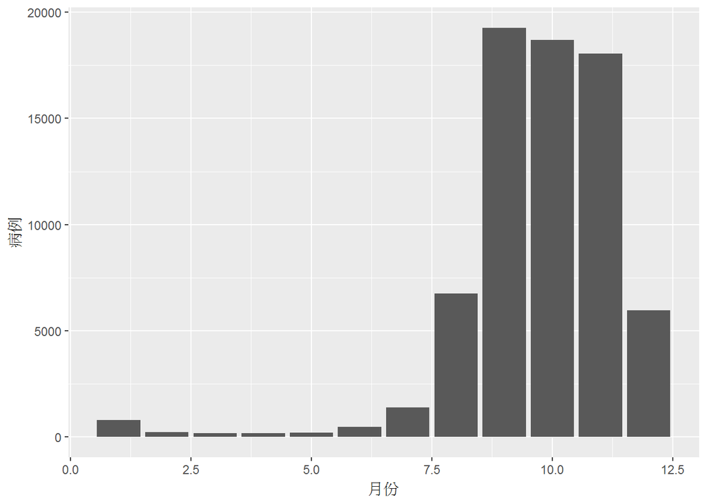

```r
library(datasets)
library(dplyr)
#install.packages("ggplot2")
library(ggplot2)
ggplot()+geom_bar(data=b,aes(x= .dots,y= 病例),
                  stat = "identity")+xlab("月份")
```

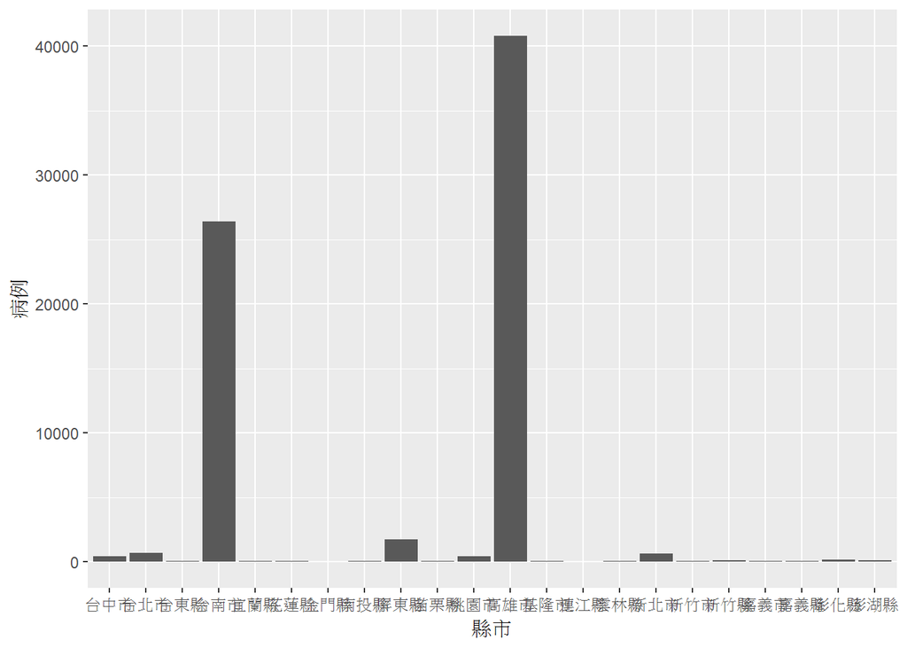

```r
ggplot()+geom_bar(data=c,aes(x= .dots,y= 病例),
                  stat = "identity")+xlab("縣市")
```

## 期末專題分析規劃 透過資料的分析了解在台灣登革熱的發生區域，進而我們還可以了解醫療資源的分配和一些疾病的預防。 之後還會再從資料中分析出台灣常見的疾病，還有地區、氣候跟疾病的關係。